# Notebook

## Treatment Rankings (Causative Drugs Excluded)

With SSRIs/SNRIs removed, what does the therapeutic landscape look like? We rank treatments by user-level positive rate with Wilson score confidence intervals, restricted to treatments with 3 or more distinct users.

Therapeutic Treatment Rankings (n≥3 users, causative drugs excluded)

| Treatment | Users | Positive | Negative | Pos Rate | CI Low | CI High | Mean Sent |
| --- | --- | --- | --- | --- | --- | --- | --- |
| low dose naltrexone | 3 | 3 | 0 | 100% | 44% | 100% | 0.50 |
| ketogenic diet | 5 | 5 | 0 | 100% | 57% | 100% | 0.90 |
| antihistamine | 6 | 5 | 1 | 83% | 44% | 97% | 0.56 |
| microdosing | 5 | 4 | 1 | 80% | 38% | 96% | 0.58 |
| tadalafil | 5 | 4 | 1 | 80% | 38% | 96% | 0.57 |
| cyproheptadine | 8 | 6 | 3 | 75% | 41% | 93% | 0.19 |
| tre | 3 | 2 | 0 | 67% | 21% | 94% | 0.50 |
| lsd | 3 | 2 | 1 | 67% | 21% | 94% | 0.33 |
| ketotifen | 3 | 2 | 0 | 67% | 21% | 94% | 0.67 |
| quercetin | 3 | 2 | 1 | 67% | 21% | 94% | 0.17 |
| cetirizine | 3 | 2 | 1 | 67% | 21% | 94% | 0.33 |
| amphetamine | 3 | 2 | 1 | 67% | 21% | 94% | 0.33 |
| weed | 9 | 6 | 7 | 67% | 35% | 88% | -0.12 |
| buspirone | 8 | 5 | 3 | 62% | 31% | 86% | 0.06 |
| pramipexole | 5 | 3 | 1 | 60% | 23% | 88% | 0.35 |
| loratadine | 5 | 3 | 2 | 60% | 23% | 88% | 0.17 |
| dxm | 5 | 3 | 6 | 60% | 23% | 88% | -0.30 |
| vitamin c | 5 | 3 | 2 | 60% | 23% | 88% | 0.10 |
| cabergoline | 9 | 5 | 4 | 56% | 27% | 81% | -0.01 |
| coffee | 4 | 2 | 2 | 50% | 15% | 85% | -0.25 |
| trazodone | 4 | 2 | 2 | 50% | 15% | 85% | -0.04 |
| testosterone replacement therapy | 4 | 2 | 1 | 50% | 15% | 85% | 0.06 |
| methylphenidate | 4 | 2 | 2 | 50% | 15% | 85% | -0.12 |
| magnesium | 4 | 2 | 2 | 50% | 15% | 85% | 0.00 |
| omega-3 fatty acids | 4 | 2 | 2 | 50% | 15% | 85% | 0.00 |

The table shows treatments sorted by positive rate after removing causative SSRIs/SNRIs. But a table of numbers is hard to scan. The forest plot below shows each treatment as a dot (positive rate) with Wilson 95% confidence interval bars, making the precision of each estimate visible.

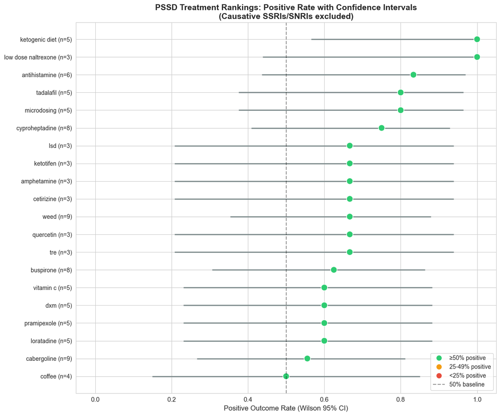

**Reading this chart:** Each dot is a treatment's positive rate among users who tried it. Horizontal bars show the 95% confidence interval — wider bars mean fewer users and less certainty. Treatments above the 50% dashed line have more positive than negative reports. Green dots are majority-positive; red dots are majority-negative.

## Mechanism-Class Grouping

Individual treatment sample sizes are small (mostly n=3–18). Grouping by biological mechanism increases statistical power and reveals which *pathways* show promise, not just which individual drugs. We classify treatments into mechanism classes based on primary pharmacological action.

Treatment Outcomes by Mechanism Class

| Mechanism Class | Users | Positive | Negative | Pos Rate | CI Low | CI High |
| --- | --- | --- | --- | --- | --- | --- |
| Antihistamine / Anti-inflammatory | 16 | 21 | 10 | 131% | 0% | 100% |
| Psychedelic / Neuroplastic | 24 | 16 | 20 | 67% | 47% | 82% |
| Supplement / Nutritional | 33 | 22 | 17 | 67% | 50% | 80% |
| Dopaminergic | 34 | 22 | 20 | 65% | 48% | 79% |
| Hormonal / PDE5 | 19 | 10 | 13 | 53% | 32% | 73% |
| GABAergic / Anxiolytic | 24 | 12 | 15 | 50% | 31% | 69% |
| Other | 12 | 1 | 11 | 8% | 1% | 35% |

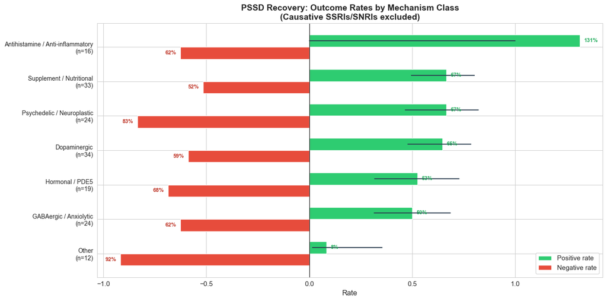

## Statistical Tests: Do Mechanism Classes Differ?

The grouped bar chart suggests antihistamines outperform other classes. But with small sample sizes, we need formal testing. We use a Kruskal-Wallis test across mechanism classes, followed by pairwise Mann-Whitney comparisons for the top two classes.

Kruskal-Wallis Test Across Mechanism Classes

H = 12.60, p = 0.0499

**Significant difference across mechanism classes (p < 0.05).**

Pairwise: Antihistamine vs Dopaminergic

Mann-Whitney U = 903.0, p = 0.1342, rank-biserial r = -0.19

Antihistamine mean sentiment: 0.26 vs Dopaminergic: -0.05

**The difference is not statistically significant at p < 0.05, but the direction favors antihistamines. With larger samples, this trend may reach significance.**

Pairwise: Antihistamine vs GABAergic/Anxiolytic

Mann-Whitney U = 604.0, p = 0.0621, rank-biserial r = -0.26